# M01-2-Introduction to Literate Programming-Application Assignment

Author

Jake Evans

Published

June 9, 2026

# 1 Introduction

This assignment introduces **literate programming** using *Quarto Markdown* in RStudio. Each exercise below combines code, output, and narrative to create a self-sufficient, reproducible document. This is due to not having access to the original document after the semester ends.

# 2 Exercises

## 2.1 Exercise 1: Create a Variable

> Create a variable called `X` and assign the text “This is my first assignment” to it.

**Tip**

Use `<-` to assign a value to a variable in R.

```r
# Assign text to variable X
X <- "This is my first assignment"
X
```

```
[1] "This is my first assignment"
```

## 2.2 Exercise 2: Adding Texts in Base R

> Since there are two sub-exercises, sub-headings are used below.

### 2.2.1 2.1 Exploring the `paste()` Function

> Look up the `paste()` function from help and run some example code from the documentation.

**Tip**

Use `?paste` in the console to open the help page. Examples are at the bottom.

**Note**

Adding ‘?’ in front of a command will bring up the R Studio help menu.

```r
# Examples from the paste() help documentation
paste("Hello", "World")
```

```
[1] "Hello World"
```

```r
paste("a", "b", "c", sep = "-")
```

```
[1] "a-b-c"
```

```r
paste(1:3, collapse = " + ")
```

```
[1] "1 + 2 + 3"
```

**Note**

Using paste0() is just a shortcut version of paste() with no separator between the strings. So:

```r
paste0("x", 1:3)
```

```
[1] "x1" "x2" "x3"
```

### 2.2.2 2.2 Using `paste()` to Extend X

> Using `paste()`, add “and I’m loving it!” to `X`.

```r
# Combine X with additional text
X <- paste(X, "and I'm loving it!")
X
```

```
[1] "This is my first assignment and I'm loving it!"
```

## 2.3 Exercise 3: Create and Modify a Vector

> Create a vector called `Y` with the numbers 2, 3, 4, and 5. Then multiply it by 2 and save it back as `Y`.

```r
# Create vector Y
Y <- c(2, 3, 4, 5)

# Multiply by 2 and overwrite Y
Y <- Y * 2
Y
```

```
[1]  4  6  8 10
```

## 2.4 Exercise 4: Print X and Y

> Print both the variable `X` and the vector `Y`.

```r
# Print X and Y
X
```

```
[1] "This is my first assignment and I'm loving it!"
```

```r
Y
```

```
[1]  4  6  8 10
```

## 2.5 Exercise 5: Max and Min of Y

> Show the maximum and minimum values of vector `Y`.

```r
# Max of Y
max(Y)
```

```
[1] 10
```

```r
# Min of Y
min(Y)
```

```
[1] 4
```

## 2.6 Exercise 6: Load ggplot2 and Preview the `economics` Dataset

> Load the `ggplot2` package and view the first six rows of the `economics` dataset.

**Tip**

If you have already installed `ggplot2`, you can comment out the `install.packages()` line.

```r
# install.packages("ggplot2") # Uncomment if not yet installed
library(ggplot2)
head(economics)
```

```
# A tibble: 6 × 6
  date         pce    pop psavert uempmed unemploy
  <date>     <dbl>  <dbl>   <dbl>   <dbl>    <dbl>
1 1967-07-01  507. 198712    12.6     4.5     2944
2 1967-08-01  510. 198911    12.6     4.7     2945
3 1967-09-01  516. 199113    11.9     4.6     2958
4 1967-10-01  512. 199311    12.9     4.9     3143
5 1967-11-01  517. 199498    12.8     4.7     3066
6 1967-12-01  525. 199657    11.8     4.8     3018
```

## 2.7 Exercise 7: Visualizing the `economics` Dataset

> Understand the dataset via the help document, define its variables, select two related variables, and create a chart.

**Note**

Use `?economics` in the console to view the full help documentation for this dataset.

**Variable Definitions:**

- **date** — Month of the data collection
- **pce** — Personal consumption expenditures (in billions of dollars)
- **pop** — Total population (in thousands)
- **psavert** — Personal savings rate (%)
- **uempmed** — Median duration of unemployment (in weeks)
- **unemploy** — Number of unemployed individuals (in thousands)

I chose **`unemploy`** (number of unemployed) and **`uempmed`** (median unemployment duration) because they are likely positively related subce periods of high unemployment may also see longer unemployment spells.

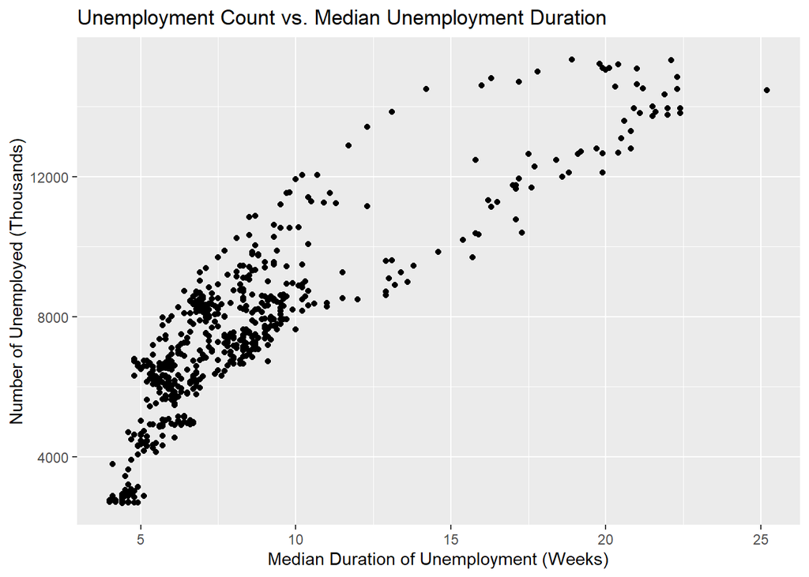

```r
# Build the base plot and assign it to 'plot'
plot <- ggplot(economics, aes(x = uempmed, y = unemploy)) +
  geom_point()

# Add title and axis labels
plot +
  labs(
    title = "Unemployment Count vs. Median Unemployment Duration",
    x = "Median Duration of Unemployment (Weeks)",
    y = "Number of Unemployed (Thousands)"
  )
```

## 2.8 Exercise 8: Replicate Chart Using Pipe Operator

> Replicate the chart above using a pipe operator in one chain of code. Add a figure label, caption, and set width to 5 with aspect ratio 0.6.

**Tip**

Use `#|` inside the code chunk to control figure options like `fig-label`, `fig-cap`, `fig-width`, and `fig-asp`.

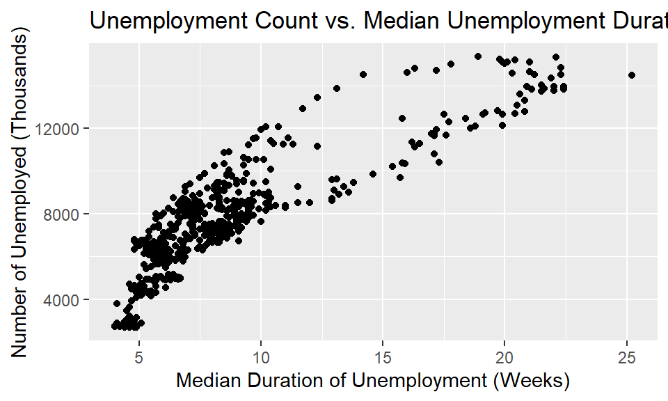

Figure 1: Scatter plot showing the relationship between median unemployment duration and total number of unemployed individuals in the U.S.

```r
# One piped chain — no intermediate plot object saved
economics |>
  ggplot(aes(x = uempmed, y = unemploy)) +
  geom_point() +
  labs(
    title = "Unemployment Count vs. Median Unemployment Duration",
    x = "Median Duration of Unemployment (Weeks)",
    y = "Number of Unemployed (Thousands)"
  )
```

## 2.9 Exercise 9: Findings

> Describe findings using a callout block with cross-referencing.

**Note**

**Findings**

As shown in Figure 1, there is a generally positive relationship between the median duration of unemployment and the total number of unemployed individuals. When unemployment spikes, people tend to remain unemployed for longer periods. Interestingly, there appear to be clusters suggesting distinct economic periods, which are likely corresponding to recessions; where both variables rise together sharply.

## 2.10 Exercise 10: Organization and Tools Used

> This section summarizes the Quarto tools used throughout this document to make it reproducible, navigable, and visually organized.

**Important**

The following tools were implemented across this report to meet the assignment requirements and improve document quality.

**Tools Implemented:**

1. **Section numbering** using `#`, `##`, and `###` for hierarchical headings
2. **Bold font** using `**text**` for emphasis on key terms and variable names
3. **Italicized font** using `*text*` for stylistic emphasis in the introduction
4. **`callout-tip`** used for hints throughout the exercises
5. **`callout-note`** used to flag the help documentation reference and findings
6. **`callout-important`** used to highlight the tools summary in Ex 10
7. **Blockquotes** (`>`) used before every task for consistent visual formatting
8. **Backtick formatting** (`` ` ``) used around function names like `paste()`, `ggplot()`, etc.
9. **Cross-referencing** with `@fig-unemployment` to refer to the figure in Ex 9
10. **`#|` chunk options** used in Ex 8 to control figure label, caption, width, and aspect ratio